# Big Data Analysis

Bagging, Random Forests and Boosting

Christoph Kern

## Setup

```r
library(tidyr)
library(foreach)
library(caret)
library(rpart)
library(randomForest)
library(xgboost)
library(pdp)
```

First, we load the Frankfurt data and remove variables that we don’t need in this notebook. We also delete rows with missing values.

```r
load("immofr.Rda")
fr_immo$place <- NULL
fr_immo$quarter <- NULL
fr_immo$frank_lon <- NULL
fr_immo$frank_lat <- NULL
fr_immo <- drop_na(fr_immo)
```

Split the data in a train and a test set.

```r
set.seed(7345)
train <- sample(1:nrow(fr_immo), 0.8*nrow(fr_immo))
fr_test <- fr_immo[-train,]
fr_train <- fr_immo[train,]
```

## Bagging

### Using foreach

To exemplify how Bagging works, we can build our own Bagging model with a foreach loop. In this loop, we first sample $n$ observations from our training data with replacement. Then, a regression tree is grown using this sample and the test set predictions from this tree are stored in the object `y_tbag`. Note that `rent ~ .` is a shortcut to include all variables in the data as predictors.

```r
y_tbag <- foreach(m = 1:100, .combine = cbind) %do% {
  rows <- sample(nrow(fr_train), replace = T)
  fit <- rpart(rent ~ ., data = fr_train[rows,], cp = 0.0001)
  predict(fit, newdata = fr_test)
}
```

Now we can compare the prediction performance of a single tree (e.g. the first) with the performance of the ensemble (the average of the predictions from all trees).

```r
postResample(y_tbag[,1], fr_test$rent)
```

```
       RMSE    Rsquared         MAE
472.2928440   0.6761379 288.9984048
```

```r
postResample(rowMeans(y_tbag), fr_test$rent)
```

```
       RMSE    Rsquared         MAE
449.3356017   0.6988456 254.3464219
```

Additionally, we summarize the row variances of all test set predictions.

```r
summary(apply(y_tbag,1,var))
```

```
   Min. 1st Qu.  Median    Mean 3rd Qu.    Max.
   3320   13368   25184   63641   51580 2168318
```

Instead of Bagging Trees, we can also plug a linear regression model into the foreach loop.

```r
y_rbag <- foreach(m = 1:100, .combine = cbind) %do% {
  rows <- sample(nrow(fr_train), replace = T)
  fit <- lm(rent ~ ., data = fr_train[rows,])
  predict(fit, newdata = fr_test)
}
```

However, Bagging is typically more effective with trees than with linear regression. We can check whether this is the case here by again comparing the performance of a single model with the performance of the ensemble.

```r
postResample(y_rbag[,1], fr_test$rent)
```

```
       RMSE    Rsquared         MAE
464.6671275   0.6867599 295.4387545
```

```r
postResample(rowMeans(y_rbag), fr_test$rent)
```

```
       RMSE    Rsquared         MAE
457.0778940   0.6899884 287.6831408
```

Again, summarize the row variances.

```r
summary(apply(y_rbag,1,var))
```

```
    Min.  1st Qu.   Median     Mean  3rd Qu.     Max.
   383.9   1367.2   2639.0   5171.6   5258.5 118082.9
```

### Using caret

Fortunately, we can use the `caret` package for building prediction models with predefined functions. For this, we first specify our evaluation method. In the following, we use 5-Fold Cross-Validation.

```r
ctrl  <- trainControl(method = "cv",
                      number = 5,
                      verboseIter = TRUE)
```

Next, we store the number of predictors of our model in the object `ncols`.

```r
ncols <- ncol(model.matrix(rent ~ .,
                           data = fr_train)[,-1])
```

This can be passed on to `train`, along with the specification of the model and the method. For Bagging Trees, we use `rf` (Random Forest) and fix the number of `mtry` (the number of features to sample at each split) to the number of predictor variables we have available.

```r
set.seed(7324)
bag <- train(rent ~ .,
             data = fr_train,
             method = "rf",
             trControl = ctrl,
             tuneGrid = data.frame(mtry = ncols),
             importance = TRUE)
```

The results of the training process can be inspected by simply calling the corresponding object. Since we fixed the tuning parameter to a single value, the CV Error for just one model is returned.

```r
bag
```

```
Random Forest

1600 samples
  15 predictors

No pre-processing
Resampling: Cross-Validated (5 fold)
Summary of sample sizes: 1281, 1280, 1280, 1279, 1280
Resampling results:

  RMSE      Rsquared   MAE
  453.9934  0.7783085  241.3941

Tuning parameter 'mtry' was held constant at a value of 15
```

Plotting the final model gives us an idea how the error evolves as more trees are added.

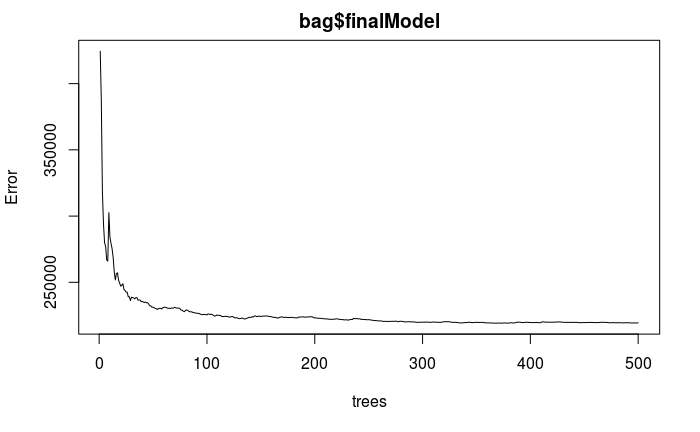

```r
plot(bag$finalModel)
```

Calculating variable importance helps us interpreting results from ensemble methods since now we have grown a lot of trees.

```r
varImp(bag)
```

```
rf variable importance

                  Overall
m2                100.000
dist_to_center     44.246
lon                24.729
voteshare_spd      19.233
lat                15.477
rooms              12.518
unemployment_rate  12.449
voteshare_fdp      11.202
number_doctors      7.990
voteshare           7.659
voteshare_left      6.272
voteshare_greens    6.246
voteshare_cdu       5.210
voteshare_afd       3.070
kita_number         0.000
```

We can take a look at the individual trees of the Bagging ensemble using `getTree`. Here we look at the first ten rows of the first two trees.

```r
getTree(bag$finalModel, k = 1, labelVar = T)[1:10,]
```

|  | left daughter | right daughter | split var | split point | status | prediction |
| --- | --- | --- | --- | --- | --- | --- |
| 1 | 2 | 3 | m2 | 109.500000 | -3 | 1306.2379 |
| 2 | 4 | 5 | m2 | 67.790000 | -3 | 1057.0776 |
| 3 | 6 | 7 | m2 | 183.045000 | -3 | 2485.9537 |
| 4 | 8 | 9 | m2 | 29.500000 | -3 | 840.3491 |
| 5 | 10 | 11 | number_doctors | 21.000000 | -3 | 1307.3937 |
| 6 | 12 | 13 | m2 | 147.500000 | -3 | 2198.4644 |
| 7 | 14 | 15 | dist_to_center | 1.595627 | -3 | 4366.2886 |
| 8 | 16 | 17 | lat | 50.120767 | -3 | 629.3794 |
| 9 | 18 | 19 | dist_to_center | 3.188187 | -3 | 885.1441 |
| 10 | 20 | 21 | m2 | 85.040000 | -3 | 1070.4408 |

```r
getTree(bag$finalModel, k = 2, labelVar = T)[1:10,]
```

|  | left daughter | right daughter | split var | split point | status | prediction |
| --- | --- | --- | --- | --- | --- | --- |
| 1 | 2 | 3 | m2 | 132.500000 | -3 | 1357.6143 |
| 2 | 4 | 5 | m2 | 79.800000 | -3 | 1132.6382 |
| 3 | 6 | 7 | rooms | 10.000000 | -3 | 3275.2677 |
| 4 | 8 | 9 | m2 | 47.800000 | -3 | 912.1025 |
| 5 | 10 | 11 | m2 | 116.500000 | -3 | 1506.8429 |
| 6 | 12 | 13 | m2 | 181.545000 | -3 | 3187.0957 |
| 7 | 0 | 0 | NA | 0.000000 | -1 | 18000.0000 |
| 8 | 14 | 15 | voteshare_fdp | 13.350000 | -3 | 722.0291 |
| 9 | 16 | 17 | voteshare_spd | 19.700000 | -3 | 1027.2984 |
| 10 | 18 | 19 | dist_to_center | 3.811518 | -3 | 1423.4162 |

## Random Forest

Now we use `rf` as intended, i.e. we use `mtry` values that are smaller than the total number of features.

```r
grid <- expand.grid(mtry = c(floor(log(ncols)), floor(sqrt(ncols))))
grid
```

| mtry |
| --- |
| 2 |
| 3 |

We can pass this sequence of `mtry` values to `train()` a random forest.

```r
set.seed(7324)
rf <- train(rent ~ .,
            data = fr_train,
            method = "rf",
            trControl = ctrl,
            tuneGrid = grid,
            importance = TRUE)
```

Now calling the random forest object lists the results of the tuning process.

```r
rf
```

```
Random Forest

1600 samples
  15 predictors

No pre-processing
Resampling: Cross-Validated (5 fold)
Summary of sample sizes: 1281, 1280, 1280, 1279, 1280
Resampling results across tuning parameters:

  mtry  RMSE      Rsquared   MAE
  2     552.4203  0.7102845  287.6129
  3     490.6897  0.7599503  256.6871

RMSE was used to select the optimal model using the smallest value.
The final value used for the model was mtry = 3.
```

With random forests, the individuals trees of the ensemble should look quite different.

```r
getTree(rf$finalModel, k = 1, labelVar = T)[1:10,]
```

|  | left daughter | right daughter | split var | split point | status | prediction |
| --- | --- | --- | --- | --- | --- | --- |
| 1 | 2 | 3 | dist_to_center | 2.233718 | -3 | 1378.412 |
| 2 | 4 | 5 | rooms | 2.750000 | -3 | 1717.032 |
| 3 | 6 | 7 | rooms | 3.750000 | -3 | 1142.492 |
| 4 | 8 | 9 | m2 | 67.670000 | -3 | 1077.179 |
| 5 | 10 | 11 | voteshare | 76.000000 | -3 | 2274.852 |
| 6 | 12 | 13 | rooms | 2.250000 | -3 | 1003.536 |
| 7 | 14 | 15 | rooms | 4.750000 | -3 | 1939.500 |
| 8 | 16 | 17 | lat | 50.098968 | -3 | 979.156 |
| 9 | 18 | 19 | voteshare_afd | 6.700000 | -3 | 1534.619 |
| 10 | 20 | 21 | lat | 50.115604 | -3 | 3360.833 |

```r
getTree(rf$finalModel, k = 2, labelVar = T)[1:10,]
```

|  | left daughter | right daughter | split var | split point | status | prediction |
| --- | --- | --- | --- | --- | --- | --- |
| 1 | 2 | 3 | rooms | 4.250000 | -3 | 1365.0286 |
| 2 | 4 | 5 | voteshare_greens | 13.500000 | -3 | 1247.6724 |
| 3 | 6 | 7 | m2 | 460.000000 | -3 | 3594.7971 |
| 4 | 8 | 9 | voteshare_cdu | 30.300000 | -3 | 975.1637 |
| 5 | 10 | 11 | rooms | 2.750000 | -3 | 1378.0948 |
| 6 | 12 | 13 | dist_to_center | 3.494347 | -3 | 3412.4528 |
| 7 | 0 | 0 | NA | 0.000000 | -1 | 18000.0000 |
| 8 | 14 | 15 | unemployment_rate | 5.250000 | -3 | 908.6651 |
| 9 | 16 | 17 | voteshare_cdu | 30.500000 | -3 | 1147.4775 |
| 10 | 18 | 19 | voteshare_fdp | 16.200000 | -3 | 1004.8115 |

Especially for ensemble methods, plots can be useful in order to see how the features are related to the outcome according to the fitted model. This can be done separately by predictor…

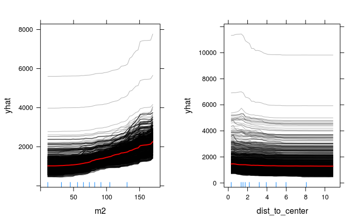

```r
pdp3 <- partial(rf, pred.var = "m2", ice = T, trim.outliers = T)
pdp4 <- partial(rf, pred.var = "dist_to_center", ice = T, trim.outliers = T)
p1 <- plotPartial(pdp3, rug = T, train = fr_train, alpha = 0.3)
p2 <- plotPartial(pdp4, rug = T, train = fr_train, alpha = 0.3)
grid.arrange(p1, p2, ncol = 2)
```

…and also by considering multiple predictors jointly.

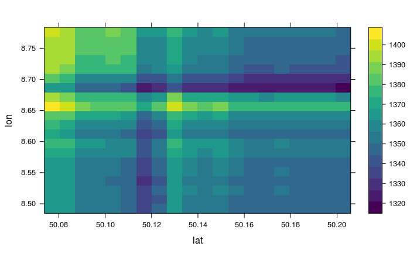

```r
pdp5 <- partial(rf, pred.var = c("lat", "lon"), grid.resolution = 20)
plotPartial(pdp5)
```

## Boosting

For Gradient Boosting, we have to take care of a couple of tuning parameters. Here, we use `xgboost` and build a grid with all combinations of a set of tryout values. See `?xgboost` for information on the available tuning parameters.

```r
grid <- expand.grid(max_depth = 1:3,
                    nrounds = c(250, 500),
                    eta = c(0.05, 0.01),
                    min_child_weight = 5,
                    subsample = 0.7,
                    gamma = 0,
                    colsample_bytree = 1)
grid
```

| max_depth | nrounds | eta | min_child_weight | subsample | gamma | colsample_bytree |
| --- | --- | --- | --- | --- | --- | --- |
| 1 | 250 | 0.05 | 5 | 0.7 | 0 | 1 |
| 2 | 250 | 0.05 | 5 | 0.7 | 0 | 1 |
| 3 | 250 | 0.05 | 5 | 0.7 | 0 | 1 |
| 1 | 500 | 0.05 | 5 | 0.7 | 0 | 1 |
| 2 | 500 | 0.05 | 5 | 0.7 | 0 | 1 |
| 3 | 500 | 0.05 | 5 | 0.7 | 0 | 1 |
| 1 | 250 | 0.01 | 5 | 0.7 | 0 | 1 |
| 2 | 250 | 0.01 | 5 | 0.7 | 0 | 1 |
| 3 | 250 | 0.01 | 5 | 0.7 | 0 | 1 |
| 1 | 500 | 0.01 | 5 | 0.7 | 0 | 1 |

[output cut: 2 more lines]

Again, this is passed on to `train`, now using `xgbTree` instead of `rf`.

```r
set.seed(7324)
xgb <- train(rent ~ .,
             data = fr_train,
             method = "xgbTree",
             trControl = ctrl,
             tuneGrid = grid)
```

Instead of just printing the results from the tuning process, we can also plot them.

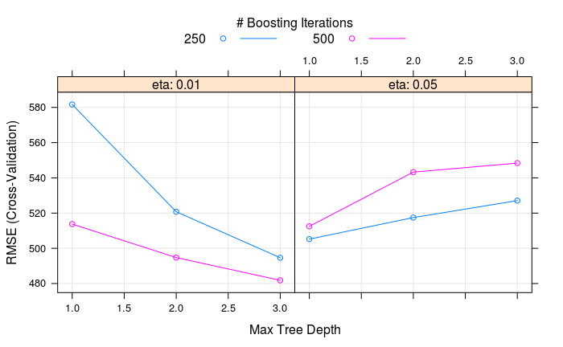

```r
plot(xgb)
```

## CART

Adding a single tree for comparison…

```r
grid <- expand.grid(maxdepth = 1:30)

set.seed(7324)
cart <- train(rent ~ .,
              data = fr_train,
              method = "rpart2",
              trControl = ctrl,
              tuneGrid = grid)
```

## Linear regression

…and also a linear regression model.

```r
set.seed(7324)
reg <- train(rent ~ .,
             data = fr_train,
             method = "glm",
             trControl = ctrl)
```

We may want to take a glimpse at the regression results.

```r
summary(reg)
```

```
Call:
NULL

Deviance Residuals:
    Min       1Q   Median       3Q      Max
-1960.3   -241.5    -44.9    182.8   6882.3

Coefficients:
                    Estimate Std. Error t value Pr(>|t|)
(Intercept)         538.3821 37860.1476   0.014 0.988656
m2                   20.2845     0.4602  44.081  < 2e-16 ***
rooms              -134.1708    17.3891  -7.716 2.11e-14 ***
lon               -1666.3140   473.6468  -3.518 0.000447 ***
lat                 390.1431   808.0909   0.483 0.629307
kita_number          -5.0529     2.0939  -2.413 0.015930 *
number_doctors        0.4585     0.6135   0.747 0.454929
unemployment_rate   -25.3881    22.4692  -1.130 0.258686
voteshare           -13.6186    10.2109  -1.334 0.182484
voteshare_cdu       -51.2921    53.8285  -0.953 0.340796
voteshare_spd       -49.0738    44.4960  -1.103 0.270247
voteshare_afd       -65.1137    52.0978  -1.250 0.211544
voteshare_left      -39.0017    61.9871  -0.629 0.529315
voteshare_greens    -42.8013    47.7008  -0.897 0.369702
voteshare_fdp       -13.7917    44.4675  -0.310 0.756486
dist_to_center      -55.8938    15.2808  -3.658 0.000263 ***
---
Signif. codes:  0 ‘***’ 0.001 ‘**’ 0.01 ‘*’ 0.05 ‘.’ 0.1 ‘ ’ 1

(Dispersion parameter for gaussian family taken to be 210424.9)

    Null deviance: 1466894567  on 1599  degrees of freedom
Residual deviance:  333313083  on 1584  degrees of freedom
AIC: 24170

Number of Fisher Scoring iterations: 2
```

## Comparison

After we ran a bunch of models, we can use `resamples()` to gather the cross-validation results from all of them.

```r
resamps <- resamples(list(Bagging = bag,
                          RandomForest = rf,
                          Boosting = xgb,
                          CART = cart,
                          Regression = reg))
```

This object can now be used for comparing these models with respect to their performance, based on CV in the training set.

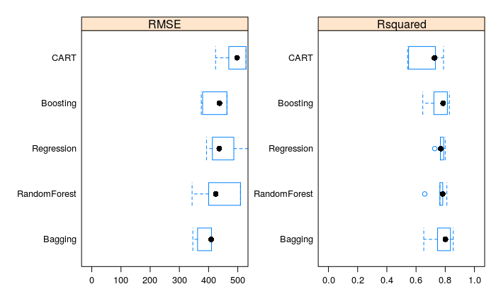

```r
bwplot(resamps, metric = c("RMSE", "Rsquared"), scales = list(relation = "free"), xlim = list(c(0, 500), c(0, 1)))
```

## Prediction

Finally, we can predict the outcome in the test data and evaluate the models based on their test set performance.

```r
y_bag <- predict(bag, newdata = fr_test)
y_rf <- predict(rf, newdata = fr_test)
y_xgb <- predict(xgb, newdata = fr_test)
y_cart <- predict(cart, newdata = fr_test)
y_reg <- predict(reg, newdata = fr_test)
postResample(pred = y_bag, obs = fr_test$rent)
```

```
       RMSE    Rsquared         MAE
460.3152126   0.6900609 251.1548384
```

```r
postResample(pred = y_rf, obs = fr_test$rent)
```

```
       RMSE    Rsquared         MAE
447.3283573   0.6964132 264.0082536
```

```r
postResample(pred = y_xgb, obs = fr_test$rent)
```

```
       RMSE    Rsquared         MAE
449.4105820   0.6954734 255.1780085
```

```r
postResample(pred = y_cart, obs = fr_test$rent)
```

```
       RMSE    Rsquared         MAE
521.6238217   0.6049612 304.7426446
```

```r
postResample(pred = y_reg, obs = fr_test$rent)
```

```
       RMSE    Rsquared         MAE
457.8202149   0.6896412 288.4671319
```